# Decision Models on a DNS Question

Can a model tell which unfamiliar hostnames are ads? I asked five of them.

I installed a Pi-hole to block ads, but the Pi-hole blocks only hostnames that are on its blocklists. Anything else is forwarded upstream and resolves, which is how an ad exchange got into an iPhone app on 4 Oct. Deciding whether an unlisted hostname is an ad is something that can be quickly identified on screen, and a new kind of model is built for exactly that.

A **decision model** is sent one hostname and typed questions. It returns typed answers with probabilities that code can branch on, so there is nothing to parse and no prompt to coax.

## Five Models, One Job

I gave the same job to four decision models and one chatbot. The Decisions API (gpt-6-luna) is OpenAI’s new public beta. Jev, from TypeSafe, already runs my weekly check. The two Strands deciders are open models that run on my own Mac. Anthropic’s Sonnet, a general chatbot, came along as a reference point.

| Model | Runs on | Price |
| --- | --- | --- |
| Decisions API (gpt-6-luna) | OpenAI’s cloud | $0.10 per 1M input tokens |
| Jev | TypeSafe’s cloud | not published |
| Strands 2B and E4B | my Mac, offline | free |
| Sonnet (reference) | Anthropic’s cloud | per token |

## The Test

Each model saw only a hostname and three questions. What is its main purpose: advertising, tracking, malicious, or something harmless? How unwanted is it, from 0 to 4? Is it run by an ad-tech company? None of them could look anything up. I asked the decision models twice, with the options in reverse order, to catch any that favour whichever option comes first.

I used two sets of hostnames. 36 were labelled by hand, 25 ad and tracking hosts and 11 ordinary sites, so they have right answers. The other 232 are what my household’s devices actually looked up over two weeks in October. They show where the models agree, and they stay private. Five appear in both sets, so the models answered 263 hostnames in all.

## Who Spotted the Ads

On the 36 labelled hostnames, the Decisions API and Sonnet put all 25 ad and tracking hosts in a blocking category. Jev got 24, missing only 3lift.com. The Strands models managed 7 (2B) and 14 (E4B), calling many well-known ad exchanges “unknown” or “content”. Not one model put an ordinary site in a blocking category.

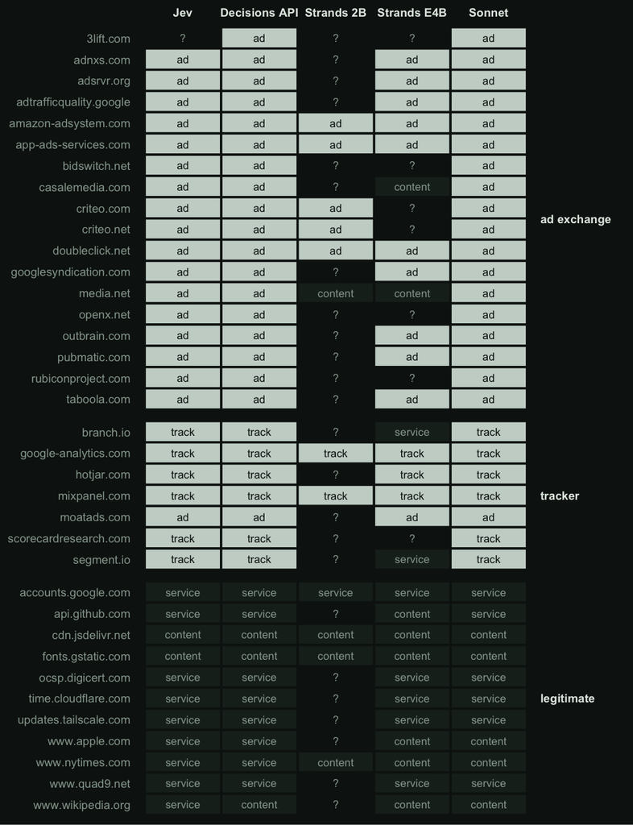

Each tile is one model’s answer for one labelled hostname. Light tiles are blocking categories; “?” means unknown.

The gap is about knowledge, not technique. A bare name like openx.net carries no clue of its own: a model either knows the company or it doesn’t, and the small models mostly don’t.

## Knowing Versus Being Sure

A decision model also says how sure it is, so a program can act on the easy cases and pass the hard ones to a person. Across all 263 hostnames, Jev’s median confidence was 0.81 and the Decisions API’s 0.71. The Strands models sat at 0.49 and 0.41 and almost never reached 0.85, so nearly everything they answered would land on my desk. Reversing the options changed few answers for any model: 11 to 32 of 263.

The Decisions API has one quirk: it reads questions literally. Asked whether analytics companies such as Mixpanel and Hotjar are ad-tech, it says no. Of the 7 labelled trackers, Jev put 5 over even odds on that question and the Decisions API put 2. Neither is wrong; it depends on what you meant to ask.

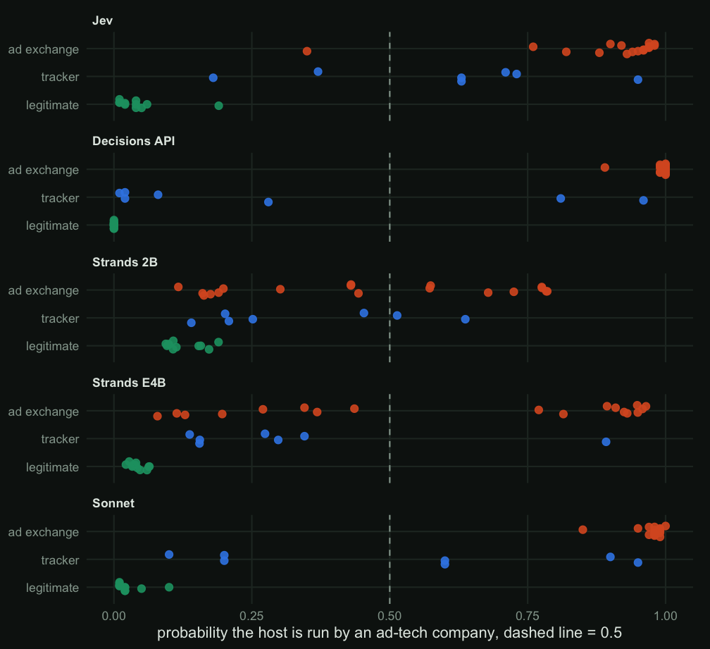

Each dot is one labelled hostname: ad exchanges, trackers and ordinary sites. Further right means the model is surer an ad-tech company runs it.

Sonnet gives a confidence only because the prompt asks for one. It’s just a number in its reply, never below 0.70, so a program can’t use it to sort easy answers from hard ones.

## From Answers to Blocks

My weekly check doesn’t block on the category alone. It proposes a block only when both option orders agree on a blocking category with confidence of at least 0.85, and the ad-tech or unwanted answer agrees too. Anything doubtful comes to me, and nothing is ever unblocked. I tuned that rule for Jev, so it favours Jev.

The unwanted score separates the groups for Jev, the Decisions API and Sonnet, but most trackers sit at the scale’s “third-party analytics” level of 2, under the rule’s 2.5 line: only 1 of 7 for Jev and 1 for the Decisions API reach it. Strands 2B squeezes everything into a narrow band, so no line separates its ads from its ordinary sites.

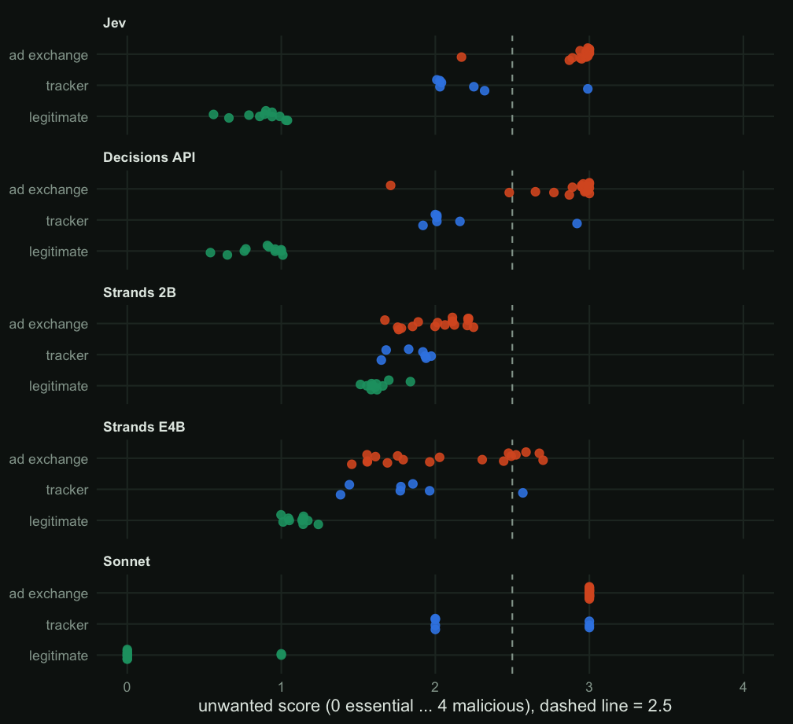

On the 36 labelled hosts, Jev would have proposed 20 blocks and the Decisions API 16. Counting reviews as well, Jev flagged 24 of the 25 ad and tracking hosts and the Decisions API all 25. The Strands models proposed none. No model proposed blocking an ordinary site.

On my household’s 232 hostnames, every pair of decision models gave the same verdict at least 91% of the time, and all four left 209 alone. Jev proposed one block and sent 18 to review; the Decisions API sent 7 to review. The worst mistake came from Strands 2B, which called a well-known app’s own service hostnames malicious.

## What It Costs

The Decisions API is the only one here with a published price: about $0.02 for all 263 hostnames, at 0.42 seconds each. Jev took 0.30 seconds, but TypeSafe doesn’t publish its price. The Strands models are free and keep every hostname on my Mac, but take 0.66 and 2.29 seconds on its GPU. Only hostnames ever left the house, never device names or addresses.

## What I’d Do Now

Jev stays my weekly check. The Decisions API is a strong second opinion: it caught every ad and tracker host, raised no false alarms, and costs pennies. The small Strands models aren’t ready for this job. They don’t know enough company names, and they’re rarely sure enough to act on. Sonnet knows the names too, but without a usable confidence, a program can’t tell its easy answers from its hard ones.

The fine print: 36 well-known hostnames make a demonstration, not a benchmark, and one or two either way is noise. My household’s hostnames have no answer key, so agreement there isn’t accuracy. The answers come from tests on 4 and 18 October 2026, and the Decisions API is in beta and may change. Every number, model by model, is in `results/report.md` in the repo. The same results as a story: OpenAI’s Decisions API, put to a household test.